# Descision Trees in Python

## Trees

Vamos a considerar el siguiente tipo de arboles (matematicos):

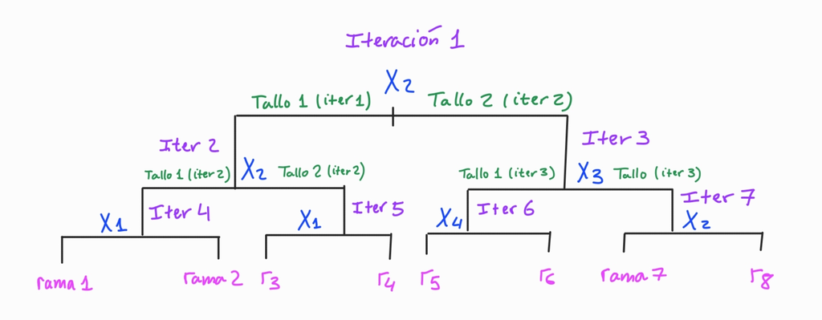

```python
from IPython.display import Image
Image(filename='arbol.jpg', width = 1000, height = 400)
```

Es importante tener en cuenta los elementos que estan reflejados, pues los usaremos posteriormente.

Los arboles estan compuestos de iteraciones, que a su vez cada una de ellas se dividen en dos tallos. La union de tallos de distintas iteraciones da lugar a las ramas del arbol.

## Regression Trees

La idea de los algoritmos de arboles de regresion es segmentar las observaciones de los predictores $X_1,...,X_p$ para predecir el valor de la respuesta $Y$ en base a esa informacion segmentada. Es algo asi como predecir $Y$ por grupos/segmentos.

### Definicion formal de un arbol de regresion:

#### **Elementos Básicos**

- Tenemos unos predictores $\hspace{0.1cm} X_1,...,X_p \hspace{0.1cm}$ y una variable respuesta **cuantitativa** $\hspace{0.1cm}Y$
- Tenemos un arbol $\hspace{0.1cm} T \hspace{0.1cm}$ de la forma del expuesto en la imagen con $\hspace{0.1cm} m-1 \hspace{0.1cm}$ iteraciones y $\hspace{0.1cm} m \hspace{0.1cm}$ ramas.
- $r_{ht}\hspace{0.1cm}$ es la rama $h$ del arbol con $t$ iteraciones.
- Cada iteracion del arbol tiene asociado uno de los predictores $\hspace{0.07cm} X_1,...,X_n$
- Cada iteracion del arbol tiene dos tallos (tallo 1 (izquierdo) y tallo 2 (derecho)).
- En cada tallo de una iteracion se define un intervalo.
- $\hspace{0.1cm} I_{lt} \hspace{0.1cm}$ es el intervalo asociado al tallo $l$ de la iteracion $\hspace{0.1cm} t$ , con $\hspace{0.1cm}l = 0,1$
- Para simplificar el problema consideraremos $\hspace{0.1cm} I_{1t} = (-\infty \hspace{0.03cm},\hspace{0.03cm} s_t)\hspace{0.1cm}$ y $\hspace{0.1cm} I_{2t} = [s_t \hspace{0.03cm},\hspace{0.03cm} \infty]\hspace{0.1cm}$ donde $\hspace{0.1cm} s_t \hspace{0.1cm}$ es llamado punto de corte de la iteracion $\hspace{0.1cm} t \hspace{0.1cm}$ del arbol
- $R_{ht} \hspace{0.1cm}$ es la region (rectangulo $p$-dimensional) definida por la rama $\hspace{0.1cm} h \hspace{0.1cm}$ de un arbol con $t$ iteraciones

Por ejemplo, considerando el arbol de arriba:

$R_{17} = \lbrace (v_1,...,v_p) \hspace{0.15cm}/\hspace{0.15cm} v_2 \in I_{11} \hspace{0.15cm} \text{y} \hspace{0.15cm} v_2 \in I_{12} \hspace{0.15cm} \text{y} \hspace{0.15cm} v_1 \in I_{14} \hspace{0.15cm} \rbrace \hspace{0.1cm}$

$R_{57} = \lbrace (v_1,...,v_p) \hspace{0.15cm}/\hspace{0.15cm} v_2 \in I_{21} \hspace{0.15cm} \text{y} \hspace{0.15cm} v_3 \in I_{13} \hspace{0.15cm} \text{y} \hspace{0.15cm} v_4 \in I_{16} \hspace{0.15cm} \rbrace \hspace{0.1cm}$

#### **Criterio de prediccion de la variable respuesta**

Dada una nueva observacion $\hspace{0.1cm} x_{new}= (x_{new,1},x_{new,2},...,x_{new,p} ) \hspace{0.1cm}$ la idea es predecir $\hspace{0.1cm} y_{new} \hspace{0.1cm}$ como sigue:

$$Si \hspace{0.3cm} x_{new} \in R_{ht} \hspace{0.22cm} \Rightarrow \hspace{0.22cm} \widehat{y}_{new} = \widehat{y}_{R_{ht}} = \dfrac{1}{\# \lbrace i / x_i \in R_{ht} \rbrace} \cdot \sum_{i / x_i \in R_{ht}} y_i $$

Es decir, para una observacion que cae en la rama $R_{ht}$ el modelo predice su valor de la respuesta como la media de los valores de la respuesta de las observaciones de train que pertenecen a esa misma rama.

$\widehat{y}_{R_{ht}}$ es la prediccion de la variable respuesta que un arbol de regresion con $t$ iteraciones hace para las observaciones que caen en la rama $h$ de dicho arbol.

#### **Objetivo**

Definimos el **error de entrenamiento de la rama $h$ de un arbol de regresion con $t$ iteraciones** como el error cometido por ese arbol de regresion al predecir la respuesta para las observaciones de entrenamiento que caen en la rama $h$ , y esto se mide como la suma de los cuadrados de los errores de prediccion de la respuesta para las observaciones que caen en la rama $h$ :

$$SSR(R_{ht}) = \sum_{ i \hspace{0.05cm}/\hspace{0.05cm} x_i \in R_{ht} } (y_i - \widehat{y}_{R_{ht}})^2$$

*Observación:*

El error de prediccion de la respuesta para un individuo $i$ de la muestra tal que $\hspace{0.1cm} x_i \in R_{ht} \hspace{0.1cm}$ es $\hspace{0.1cm} y_i - \widehat{y}_{R_{ht}} \hspace{0.1cm}$ , ya que $\hspace{0.1cm} \widehat{y}_{R_{ht}} \hspace{0.1cm}$ es la prediccion de la respuesta que este modelo hace para los individuos que caen en $R_{ht}$ $\hspace{0.1cm}($ cuyas observaciones de los predictores, $\hspace{0.1cm}x_i\hspace{0.1cm}$, caen en $\hspace{0.1cm}R_{ht})$

Definimos el **error global de entrenamiento de un arbol de regresion con $t$** iteraciones como la suma de los errores de entrenamiento de las ramas de ese arbol de regresion:

$$\sum_{h=1}^{m} \hspace{0.1cm} SSR(R_{ht}) $$

El **objetivo** es construir un arbol de regresion con con $t$ iteraciones y $m$ ramas tal que **minimice** el **error global de entrenamiento**.

Es decir, formalmente el objetivo es:

$$ \underset{R_{1t},..,R_{mt}}{Min} \hspace{0.12cm} \sum_{h=1}^{m} \hspace{0.1cm} SSR(R_{ht}) $$

Pero para escoger las regiones $\hspace{0.1cm} R_{1t},...,R_{mt} \hspace{0.1cm}$ que definen las ramas del arbol hay que determinar dos elementos que definen a su vez a las regiones:

$1.\hspace{0.1cm}$ Qué predictores estan asociados a cada iteracion del arbol $\hspace{0.1cm} \Rightarrow \hspace{0.1cm}$ Para cada iteracion $i$ escoger $X_j \hspace{0.01cm}$ $(\hspace{0.01cm} $ es decir, escoger $j \hspace{0.01cm})$

$2.\hspace{0.1cm}$ Qué intervalos estan asociados a cada uno de los dos tallos de cada interaccion $\hspace{0.1cm} \Rightarrow \hspace{0.1cm}$ Para cada iteracion $t$ escoger $I_{1t}$ y $I_{2t}\hspace{0.1cm}$ $(\hspace{0.01cm}$ es decir, escoger el punto de corte $\hspace{0.07cm}s_t \hspace{0.04cm} )$

Por tanto el porblema a resolver se puede reformular como:

Para cada iteracion $\hspace{0.1cm} t \hspace{0.1cm}$ escoger $\hspace{0.1cm} X_j\hspace{0.01cm}$ $(\hspace{0.05cm}$ es decir $\hspace{0.01cm}j \hspace{0.05cm})\hspace{0.05cm}$ y el par de intervalos $\hspace{0.05cm}( I_{1t}\hspace{0.1cm},\hspace{0.1cm}I_{2t} )\hspace{0.1cm}$ $\hspace{0.1cm}($ es decir $\hspace{0.1cm} s_t)\hspace{0.1cm}$ tal que se acaben formando un arbol cuyas $m$ ramas definan unas regiones $\hspace{0.1cm}R_{1t},...,R_{mt}\hspace{0.1cm}$ que **minimicen** $\hspace{0.1cm}\sum_{h=1}^{m} SSR(R_{ht})$

### Algoritmo para la resolucion del problema $\hspace{0.1cm}\Rightarrow\hspace{0.1cm}$ **Algoritmo de particion binaria**

El siguiente algoritmo es una forma de resolver el problema planteado anteriormente. Consiste en ir generando el arbol de manera secuencial, iteracion a iteracion, minimizando en cada paso el error de prediccion de la respuesta para las observaciones de train que caen en las ramas asociadas a la iteracion en cuestion que esta siendo optimizada. La idea es generar cada iteracion del arbol minimizando los errores de prediccion de la respuesta para len cada rama, hasta que se cumple un criterio de parada en el que no se generan mas iteraciones y el arbol queda finalizado.

El algoritmo se basa en la resolucion secuencial de problemas de minimizacion, uno por cada iteracion tenga el arbol que se acabará generando.

#### **Problema de la Iteracion 1**

Arbol con 1 iteracion:

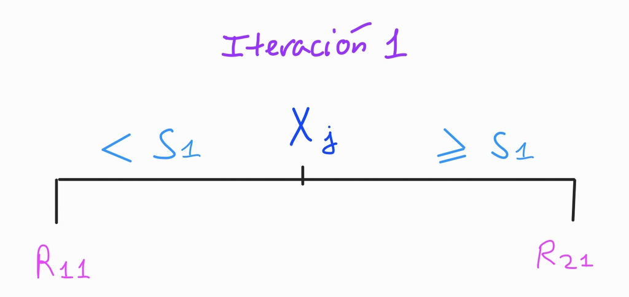

```python
from IPython.display import Image
Image(filename='arbol 1iter.jpg', width = 600, height = 300)
```

La idea es, determinar las regiones $R_{11}$ y $R_{21}\hspace{0.1cm}$ $($ es decir, $j$ y $s_1 \hspace{0.05cm}) \hspace{0.1cm}$ del arbol con 1 iteracion tal que minimizan el error de entrenamiento global de dicho arbol con 1 iteracion.

Mas formalmente el problema planteado es:

$$ \underset{R_{11} , R_{21}} {Min} \hspace{0.15cm} \left(\hspace{0.1cm} SSR_1 = SSR(R_{11}) + SSR(R_{21}) \hspace{0.1cm}\right) \hspace{0.1cm} = \\[25pt] =\hspace{0.2cm} \underset{R_{11} , R_{21}} {Min} \hspace{0.1cm} \left( \hspace{0.2cm} \sum_{ i \hspace{0.05cm}/\hspace{0.05cm} x_i \in R_{11} } (y_i - \widehat{y}_{R_{11}} )^2 \hspace{0.3cm} + \hspace{0.1cm} \sum_{ i \hspace{0.05cm}/\hspace{0.05cm} x_i \in R_{21} } (y_i - \widehat{y}_{R_{21}})^2 \hspace{0.2cm} \right) \\[25pt] =\hspace{0.2cm} \underset{j \hspace{0.02cm},\hspace{0.02cm} s_1} {Min} \hspace{0.1cm} \left( \hspace{0.2cm} \sum_{ i \hspace{0.05cm}/\hspace{0.05cm} x_{ij} \hspace{0.05cm} < \hspace{0.05cm} s_1 } (y_i - \widehat{y}_{R_{11}} )^2 \hspace{0.3cm} + \hspace{0.1cm} \sum_{ i \hspace{0.05cm}/\hspace{0.05cm} x_{ij} \hspace{0.05cm} \geqslant \hspace{0.05cm} s_1 } (y_i - \widehat{y}_{R_{21}})^2 \hspace{0.2cm} \right) $$

Notar que:

$R_{11} = \lbrace (v_1 ,..., v_p) / v_j < s_1 \rbrace \hspace{0.3cm}\Rightarrow\hspace{0.3cm} [\hspace{0.1cm} x_i=(x_{i1},...,x_{ip}) \in R_{11} \hspace{0.1cm} \Leftrightarrow \hspace{0.1cm} x_{ij} < s_1 \hspace{0.1cm}] \hspace{0.3cm}\Rightarrow\hspace{0.3cm} \lbrace i/x_i \in R_{11} \rbrace = \lbrace i / x_{ij} < s_1 \rbrace$

$ R_{12} = \lbrace (v_1 ,..., v_p) / v_j \geqslant s_1 \rbrace \hspace{0.3cm}\Rightarrow\hspace{0.3cm} [\hspace{0.1cm} x_i=(x_{i1},...,x_{ip}) \in R_{21} \hspace{0.1cm} \Leftrightarrow \hspace{0.1cm} x_{ij} \geqslant s_1 \hspace{0.1cm}] \hspace{0.3cm}\Rightarrow\hspace{0.3cm} \lbrace i/x_i \in R_{21} \rbrace = \lbrace i / x_{ij} \geqslant s_1 \rbrace$

Notese que determinar $R_{11}$ y $R_{21}$ es equivalente a determinar el predictor $X_j$ $($ es decir $j)$ y el punto de corte $s_1$ asociados a la Iteracion 1, ya que $R_{11}$ y $R_{21}$ quedan determinadas al fijar $X_j$ y $s_1$

Donde :

- $\hspace{0.2cm} j \in \lbrace 1,2,...,p \rbrace $
- Si $X_j$ es cuantitativa:

$\hspace{0.7cm}$ Ordenamos las observaciones de $X_j$ y quitamos repeticiones, obtenemos $X_j^{order}$, entonces:

$$ s_1 \in \Biggl\{ \dfrac{ x_{(1)j} + x_{(2)j} }{2} \hspace{0.1cm}, \hspace{0.1cm} \dfrac{x_{(2)j} + x_{(3)j} }{2} \hspace{0.1cm} ,...,\hspace{0.1cm} \dfrac{x_{(n-1)j} + x_{(n)j} }{2} \Biggl\}$$

$\hspace{0.7cm}$ Donde $\hspace{0.1cm} x_{(i)j} \hspace{0.1cm} $ es la observacion que ocupa la posicion $i$-esima en $\hspace{0.1cm} X_j^{order}$

- Si $X_j$ es categorica con $c$ categorias:

$$ s_1 \in Rango(X_j) = \lbrace 0,1,..., c-1 \rbrace $$

Notese que la eleccion de $X_j$ determina el campo de variacion de $s_1$

- $SSR(R_{11})$ es el error de entrenamiento de la rama $1$ de un arbol de regresion con 1 iteracion
- $SSR(R_{21})$ es el error de entrenamiento de la rama $2$ de un arbol de regresion con 1 iteracion

Por otro lado:

$$\widehat{y}_{R_{11}} \hspace{0.1cm} = \hspace{0.1cm} \dfrac{1}{\# \lbrace i / x_i \in R_{11} \rbrace} \cdot \sum_{i / x_i \in R_{11}} y_i \hspace{0.1cm} = \hspace{0.1cm} \dfrac{1}{\# \lbrace i / x_{ij} < s_1 \rbrace} \cdot \sum_{i / x_i < s_1} y_i $$

$$\widehat{y}_{R_{21}} \hspace{0.1cm} = \hspace{0.1cm} \dfrac{1}{\# \lbrace i / x_i \in R_{21} \rbrace} \cdot \sum_{i / x_i \in R_{21}} y_i \hspace{0.1cm} = \hspace{0.1cm} \dfrac{1}{\# \lbrace i / x_i \geqslant s_1 \rbrace} \cdot \sum_{i / x_i \geqslant s_1} y_i $$

$\widehat{y}_{R_{11}}$ es la prediccion de la respuesta dada por un arbol de regresion con 1 Iteracion para las observaciones que caen en la rama 1 de dicho arbol.

$\widehat{y}_{R_{21}}$ es la prediccion de la respuesta dada por un arbol de regresion con 1 Iteracion para las observaciones que caen en la rama 2 de dicho arbol.

Estos elementos no volveran a ser definidos en los sucesivos problemas de iteracion para no pecar de ser repetitivo, puesto que pueden ser facilmente extrapolados a cualquier problema de iteracion. Ademas las definiciones generales de estos elementos han sido expuestas ya anteriormente.

- Denotaremos por $\hspace{0.1cm} \left(\hspace{0.1cm} j^{*(i)} \hspace{0.05cm},\hspace{0.05cm} s^{*(i)} \hspace{0.1cm}\right) \hspace{0.1cm}$ a una solucion del problema de la Iteracion $i$ , para $i=1,...,m-1$

Arbol obtenido tras resolver el problema de la Iteracion 1:

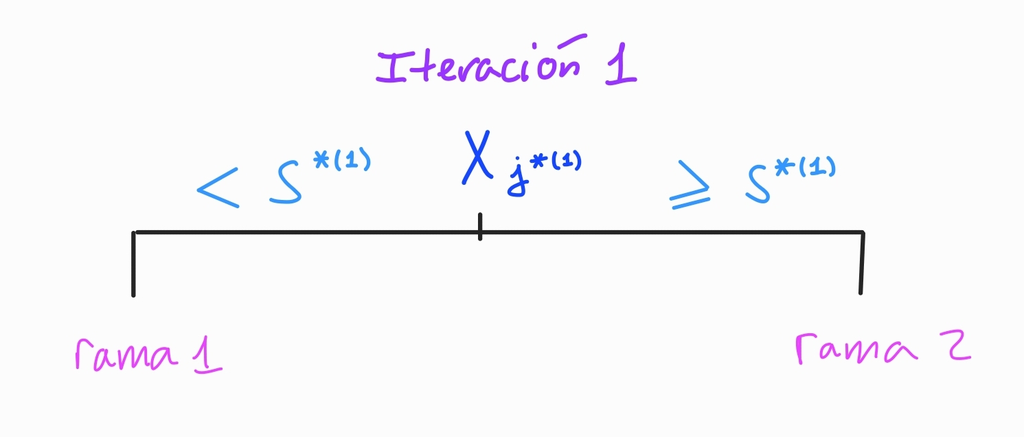

```python
from IPython.display import Image
Image(filename='iter1.jpg', width = 600, height = 300)
```

- Si alguna de las ramas del arbol resultante de resolver el problema la iteracion 1 tiene menos de $\hspace{0.05cm}k\hspace{0.05cm}$ observaciones de train $\hspace{0.1cm} \Rightarrow \hspace{0.1cm}$ se para el algoritmo
- Si todas las ramas tienen $\hspace{0.05cm}k\hspace{0.05cm}$ o mas observaciones de train $\hspace{0.1cm} \Rightarrow \hspace{0.1cm}$ el algoritmo continua, se pasa a resolver el problema de la iteracion siguiente, en este caso el de la iteracion 2

Notese que $k$ será un **hiperparametro** del algoritmo.

#### **Problema de la Iteracion 2**

Arbol con 2 iteraciones tras resolver el problema anterior:

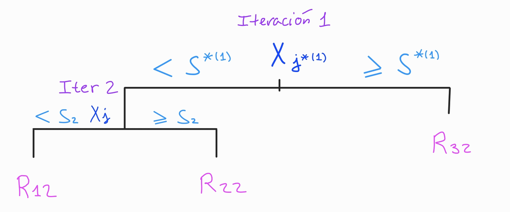

```python
from IPython.display import Image
Image(filename='arbol 2iter.jpg', width = 600, height = 300)
```

Si estamos en este problema es porque ninguna rama del arbol resultante del problema de la Iteracion 1 tiene menos de $k$ observaciones

La idea es, determinar las regiones $R_{12}$ , $R_{22}$ y $R_{32}$ del arbol con 2 iteraciones (es decir, $j$ y $s_2$), considerando la solucion del problema de la iteracion 1 (arbol de arriba) , que minimizan el error de entrenamiento global de dicho arbol.

Notese que $R_{32}$ ya esta determinada tras la resolucion del problema anterior, por ello realmente solo hay que determinar las regiones $R_{12}$ y $R_{22}$ óptimas (a saber, $j$ y $s_2$ óptimos)

Mas formalmente el problema planteado es:

$$ \underset{R_{12} , R_{22}, R_{32}} {Min} \hspace{0.15cm} \left(\hspace{0.1cm} SSR_2 = SSR(R_{12}) + SSR(R_{22}) + SSR(R_{32}) \hspace{0.1cm}\right) \hspace{0.1cm} = \\[35pt] =\hspace{0.2cm} \underset{R_{12} , R_{22}, R_{32}} {Min} \hspace{0.1cm} \left( \hspace{0.2cm} \sum_{ i \hspace{0.05cm}/\hspace{0.05cm} x_i \in R_{12} } (y_i - \widehat{y}_{R_{12}} )^2 \hspace{0.3cm} + \hspace{0.1cm} \sum_{ i \hspace{0.05cm}/\hspace{0.05cm} x_i \in R_{22} } (y_i - \widehat{y}_{R_{22}})^2 \hspace{0.3cm} + \hspace{0.1cm} \sum_{ i \hspace{0.05cm}/\hspace{0.05cm} x_i \in R_{32} } (y_i - \widehat{y}_{R_{32}})^2 \hspace{0.2cm} \right) \\[35pt] =\hspace{0.2cm} \underset{j \hspace{0.02cm},\hspace{0.02cm} s_2} {Min} \hspace{0.1cm} \left( \hspace{0.2cm} \sum_{ \substack{ i \hspace{0.05cm} / \hspace{0.05cm} x_{ij^{*(1)}} \hspace{0.05cm} < \hspace{0.05cm} s^{*(1)} \\ \\ x_{ij } \hspace{0.05cm} < \hspace{0.05cm} s_2} } (y_i - \widehat{y}_{R_{12}} )^2 \hspace{0.3cm} + \hspace{0.1cm} \sum_{ \substack{ i \hspace{0.05cm}/\hspace{0.05cm} x_{ij^{*(1)}} \hspace{0.05cm} < \hspace{0.05cm} s^{*(1)} \\ \\ x_{ij} \hspace{0.05cm} \geqslant \hspace{0.05cm} s_2 } } (y_i - \widehat{y}_{R_{22}})^2 \hspace{0.3cm} + \hspace{0.1cm} \sum_{ \substack{ i \hspace{0.05cm}/\hspace{0.05cm} x_{ij^{*(1)}} \hspace{0.05cm} \geqslant \hspace{0.05cm} s^{*(1)} } } (y_i - \widehat{y}_{R_{32}})^2 \hspace{0.2cm} \right) \\[55pt] =\hspace{0.2cm} \underset{j \hspace{0.02cm},\hspace{0.02cm} s_2} {Min} \hspace{0.1cm} \left( \hspace{0.2cm} \sum_{ \substack{ i \hspace{0.05cm} / \hspace{0.05cm} x_{ij^{*(1)}} \hspace{0.05cm} < \hspace{0.05cm} s^{*(1)} \\ \\ x_{ij } \hspace{0.05cm} < \hspace{0.05cm} s_2} } (y_i - \widehat{y}_{R_{12}} )^2 \hspace{0.3cm} + \hspace{0.1cm} \sum_{ \substack{ i \hspace{0.05cm}/\hspace{0.05cm} x_{ij^{*(1)}} \hspace{0.05cm} < \hspace{0.05cm} s^{*(1)} \\ \\ x_{ij} \hspace{0.05cm} \geqslant \hspace{0.05cm} s_2 } } (y_i - \widehat{y}_{R_{22}})^2 \hspace{0.2cm} \right) $$

Notese que el sumando:

$$ \sum_{i \hspace{0.05cm}/\hspace{0.05cm} x_{ij^{*(1)}} \hspace{0.05cm} \geqslant \hspace{0.05cm} s^{*(1)} } (y_i - \widehat{y}_{R_{32}})^2 $$

**NO** depende de $(j, s_2)$ , por lo que puede sacarse de la funcion objetivo del problema de minimizacion sin que esto altere la solucion del problema.

Arbol tras resolver el problema de la Iteracion 2:

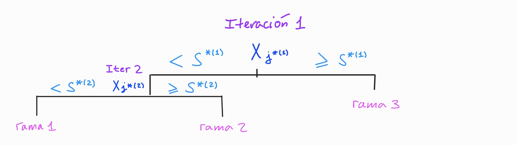

```python
from IPython.display import Image
Image(filename='iter2.jpg', width = 940, height = 320)
```

#### **Problema de la Iteracion 3**

Arbol con 3 iteraciones tras resolver el problema anterior:

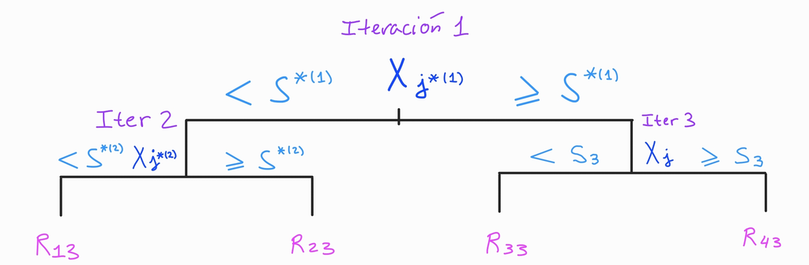

```python
from IPython.display import Image
Image(filename='arbol 3iter.jpg', width = 940, height = 320)
```

Si estamos en este problema es porque ninguna rama del arbol resultante del problema de la Iteracion 2 tiene menos de $k$ observaciones

La idea es, determinar las regiones $R_{13}$ , $R_{23}$, $R_{33}$ y $R_{43}$ del arbol con 3 iteraciones $($ es decir, $j$ y $s_3 \hspace{0.05cm})$, considerando la solucion del problema de la iteracion 2 (arbol de arriba), que minimizan el error de entrenamiento global de dicho arbol.

Notese que $R_{13}$ y $R_{23}$ ya están determinadas tras la resolucion del problema anterior, por ello realmente solo hay que determinar las regiones $R_{33}$ y $R_{43}$ óptimas (a saber, $j$ y $s_3$ óptimos)

Mas formalmente el problema se plantea como sigue:

$$ \underset{R_{13} , R_{23}, R_{33}, R_{43}} {Min} \hspace{0.15cm} \left(\hspace{0.1cm} SSR_3 = SSR(R_{13}) + SSR(R_{23}) + SSR(R_{33}) + SSR(R_{43}) \hspace{0.1cm}\right) \hspace{0.1cm} = \\[35pt] =\hspace{0.2cm} \underset{R_{13} , R_{23}, R_{33}, R_{43}} {Min} \hspace{0.1cm} \left( \hspace{0.2cm} \sum_{ i \hspace{0.05cm}/\hspace{0.05cm} x_i \in R_{13} } (y_i - \widehat{y}_{R_{13}} )^2 \hspace{0.3cm} + \hspace{0.1cm} \sum_{ i \hspace{0.05cm}/\hspace{0.05cm} x_i \in R_{23} } (y_i - \widehat{y}_{R_{23}})^2 \hspace{0.3cm} + \hspace{0.1cm} \sum_{ i \hspace{0.05cm}/\hspace{0.05cm} x_i \in R_{33} } (y_i - \widehat{y}_{R_{33}})^2 \hspace{0.3cm} + \hspace{0.1cm} \sum_{ i \hspace{0.05cm}/\hspace{0.05cm} x_i \in R_{43} } (y_i - \widehat{y}_{R_{43}})^2 \hspace{0.2cm} \right) \\[35pt] =\hspace{0.2cm} \underset{j \hspace{0.02cm},\hspace{0.02cm} s_3} {Min} \hspace{0.1cm} \left( \hspace{0.2cm} \sum_{ \substack{ i \hspace{0.05cm}/\hspace{0.05cm} x_{ij^{*(1)}} \hspace{0.05cm} < \hspace{0.05cm} s^{*(1)} \\ \\ x_{ij^{*(2)} } \hspace{0.05cm} < \hspace{0.05cm} s^{*(2)} } } (y_i - \widehat{y}_{R_{13}} )^2 \hspace{0.3cm} + \hspace{0.1cm} \sum_{ \substack{ i \hspace{0.05cm}/\hspace{0.05cm} x_{ij^{*(1)}} \hspace{0.05cm} < \hspace{0.05cm} s^{*(1)} \\ \\ x_{ij^{*(2)}} \hspace{0.05cm} \geqslant \hspace{0.05cm} s^{*(2)} } } (y_i - \widehat{y}_{R_{23}})^2 \hspace{0.3cm} + \hspace{0.1cm} \sum_{ \substack{ i \hspace{0.05cm}/\hspace{0.05cm} x_{ij^{*(1)}} \hspace{0.05cm} \geqslant \hspace{0.05cm} s^{*(1)} \\ \\ x_{ij} \hspace{0.05cm} < \hspace{0.05cm} s_3 } } (y_i - \widehat{y}_{R_{33}})^2 \hspace{0.3cm} + \hspace{0.1cm} \sum_{ \substack{ i \hspace{0.05cm}/\hspace{0.05cm} x_{ij^{*(1)}} \hspace{0.05cm} \geqslant \hspace{0.05cm} s^{*(1)} \\ \\ x_{ij} \hspace{0.05cm} \geqslant \hspace{0.05cm} s_3 } } (y_i - \widehat{y}_{R_{43}})^2 \hspace{0.2cm} \right) \\[35pt] =\hspace{0.2cm} \underset{j \hspace{0.02cm},\hspace{0.02cm} s_3} {Min} \hspace{0.1cm} \left( \hspace{0.2cm} \sum_{ \substack{ i \hspace{0.05cm}/\hspace{0.05cm} x_{ij^{*(1)}} \hspace{0.05cm} \geqslant \hspace{0.05cm} s^{*(1)} \\ \\ x_{ij} \hspace{0.05cm} < \hspace{0.05cm} s_3 } } (y_i - \widehat{y}_{R_{33}})^2 \hspace{0.3cm} + \hspace{0.1cm} \sum_{ \substack{ i \hspace{0.05cm}/\hspace{0.05cm} x_{ij^{*(1)}} \hspace{0.05cm} \geqslant \hspace{0.05cm} s^{*(1)} \\ \\ x_{ij} \hspace{0.05cm} \geqslant \hspace{0.05cm} s_3 } } (y_i - \widehat{y}_{R_{43}})^2 \hspace{0.2cm} \right) $$

Notese que los sumandos :

$$ \sum_{ \substack{ i \hspace{0.05cm}/\hspace{0.05cm} x_{ij^{*(1)}} \hspace{0.05cm} < \hspace{0.05cm} s^{*(1)} \\ x_{ij^{*(2)} } \hspace{0.05cm} < \hspace{0.05cm} s^{*(2)} }} (y_i - \widehat{y}_{R_{13}} )^2 \hspace{0.3cm} + \hspace{0.1cm} \sum_{ \substack{ i \hspace{0.05cm}/\hspace{0.05cm} x_{ij^{*(1)}} \hspace{0.05cm} < \hspace{0.05cm} s^{*(1)} \\ x_{ij^{*(2)}} \hspace{0.05cm} \geqslant \hspace{0.05cm} s^{*(2)} } } (y_i - \widehat{y}_{R_{23}})^2 $$

**NO** dependen de $(j, s_3)$ , por lo que puede sacarse de la funcion objetivo del problema de minimizacion sin que esto altere la solucion del problema.

Arbol tras resolver el problema de la Iteracion 3

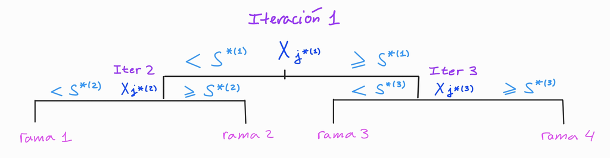

```python
from IPython.display import Image
Image(filename='iter3.jpg', width = 900, height = 300)
```

***Problema de la Iteracion 4:***

Arbol con 4 iteraciones tras resolver el problema anterior:

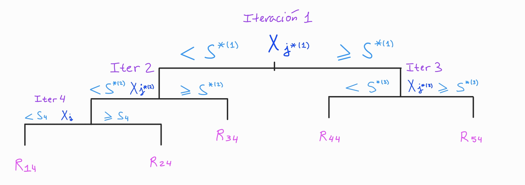

```python
from IPython.display import Image
Image(filename='arbol 4iter.jpg', width = 900, height = 400)
```

Si estamos en este problema es porque ninguna rama del arbol resultante del problema de la Iteracion 3 tiene menos de $k$ observaciones

La idea es, determinar las regiones $R_{14}$ , $R_{24}$, $R_{34}$ , $R_{44}$, $R_{54}$ del arbol con 4 iteraciones $($ es decir, $j$ y $s_4 \hspace{0.1cm} )$, considerando la solucion del problema de la iteracion 3(arbol de arriba), que minimizan el error de entrenamiento global de dicho arbol.

Notese que $R_{34}$ , $R_{44}$ y $R_{54}$ ya están determinadas tras la resolucion de los problemas anteriores, por ello realmente solo hay que determinar las regiones $R_{14}$ y $R_{24}$ óptimas (a saber, $j$ y $s_4$ óptimos)

Mas formalmente el problema se plantea como sigue:

$$ \underset{R_{14} , R_{24}, R_{34}, R_{44}, R_{54} } {Min} \hspace{0.15cm} \hspace{0.1cm} SSR_4 = SSR(R_{14}) + SSR(R_{24}) + SSR(R_{34}) + SSR(R_{44}) + SSR(R_{54}) \hspace{0.1cm} \hspace{0.1cm} = \\[35pt] =\hspace{0.2cm} \underset{R_{14} , R_{24}, R_{34}, R_{44}, R_{54} } {Min} \hspace{0.2cm} \left( \hspace{0.2cm} \sum_{ \substack{ i \hspace{0.05cm}/\hspace{0.05cm} x_i \in R_{14} } } (y_i - \widehat{y}_{R_{14}} )^2 \hspace{0.3cm} + \hspace{0.1cm} \sum_{ i \hspace{0.05cm}/\hspace{0.05cm} x_i \in R_{24} } (y_i - \widehat{y}_{R_{24}})^2 \hspace{0.3cm} + \hspace{0.1cm} \sum_{ i \hspace{0.05cm}/\hspace{0.05cm} x_i \in R_{34} } (y_i - \widehat{y}_{R_{34}})^2 \hspace{0.3cm} + \hspace{0.1cm} \sum_{ i \hspace{0.05cm}/\hspace{0.05cm} x_i \in R_{44} } (y_i - \widehat{y}_{R_{44}})^2 \hspace{0.3cm} + \hspace{0.1cm} \sum_{ i \hspace{0.05cm}/\hspace{0.05cm} x_i \in R_{54} } (y_i - \widehat{y}_{R_{54}})^2 \hspace{0.2cm} \right) \\[35pt] = \hspace{0.2cm} \underset{j \hspace{0.02cm},\hspace{0.02cm} s_4} {Min} \hspace{0.1cm} \left( \hspace{0.2cm} \sum_{\substack{ i \hspace{0.05cm}/\hspace{0.05cm} x_{ij^{*(1)}} \hspace{0.05cm} < \hspace{0.05cm} s^{*(1)} \\ \\ x_{ij^{*(2)}} \hspace{0.05cm} < \hspace{0.05cm} s^{*(2)} \\ \\ x_{ij} \hspace{0.05cm} < \hspace{0.05cm} s_4 } } (y_i - \widehat{y}_{R_{14}} )^2 \hspace{0.3cm} + \hspace{0.1cm} \sum_{ \substack{ i \hspace{0.05cm}/\hspace{0.05cm} x_{ij^{*(1)}} \hspace{0.05cm} < \hspace{0.05cm} s^{*(1)} \\ \\ x_{ij^{*(2)}} \hspace{0.05cm} < \hspace{0.05cm} s^{*(2)} \\ \\ x_{ij} \hspace{0.05cm} \geqslant \hspace{0.05cm} s_4 } } (y_i - \widehat{y}_{R_{24}})^2 \hspace{0.3cm} + \hspace{0.1cm} \sum_{ \substack{ i \hspace{0.05cm}/\hspace{0.05cm} x_{ij^{*(1)}} \hspace{0.05cm} < \hspace{0.05cm} s^{*(1)} \\ \\ x_{ij^{*(2)}} \hspace{0.05cm} \geqslant \hspace{0.05cm} s^{*(2)} } } (y_i - \widehat{y}_{R_{34}})^2 \hspace{0.3cm} + \hspace{0.1cm} \sum_{ \substack{ i \hspace{0.05cm}/\hspace{0.05cm} x_{ij^{*(1)}} \hspace{0.05cm} \geqslant \hspace{0.05cm} s^{*(1)} \\ \\ x_{ij^{*(3)}} \hspace{0.05cm} < \hspace{0.05cm} s^{*(3)} } } (y_i - \widehat{y}_{R_{44}})^2 \hspace{0.3cm} + \hspace{0.1cm} \sum_{ \substack{ i \hspace{0.05cm}/\hspace{0.05cm} x_{ij^{*(1)}} \hspace{0.05cm} \geqslant \hspace{0.05cm} s^{*(1)} \\ \\ x_{ij^{*(3)}} \hspace{0.05cm} \geqslant \hspace{0.05cm} s^{*(3)} } } (y_i - \widehat{y}_{R_{54}})^2 \hspace{0.2cm} \right) \\[35pt] =\hspace{0.2cm} \underset{j \hspace{0.02cm},\hspace{0.02cm} s_4} {Min} \hspace{0.1cm} \left( \hspace{0.2cm} \sum_{ \substack{ i \hspace{0.05cm}/\hspace{0.05cm} x_{ij^{*(1)}} \hspace{0.05cm} < \hspace{0.05cm} s^{*(1)} \\ \\ x_{ij^{*(2)}} \hspace{0.05cm} < \hspace{0.05cm} s^{*(2)} \\ \\ x_{ij} \hspace{0.05cm} < \hspace{0.05cm} s_4 } } (y_i - \widehat{y}_{R_{14}} )^2 \hspace{0.3cm} + \hspace{0.1cm} \sum_{ \substack{ i \hspace{0.05cm}/\hspace{0.05cm} x_{ij^{*(1)}} \hspace{0.05cm} < \hspace{0.05cm} s^{*(1)} \\ \\ x_{ij^{*(2)}} \hspace{0.05cm} < \hspace{0.05cm} s^{*(2)} \\ \\ x_{ij} \hspace{0.05cm} \geqslant \hspace{0.05cm} s_4 } } (y_i - \widehat{y}_{R_{24}})^2 \hspace{0.2cm} \right) $$

Notese que los sumandos:

$$ \sum_{ \substack{ i \hspace{0.05cm}/\hspace{0.05cm} x_{ij^{*(1)}} \hspace{0.05cm} < \hspace{0.05cm} s^{*(1)} \\ \\ x_{ij^{*(2)}} \hspace{0.05cm} \geqslant \hspace{0.05cm} s^{*(2)} } } (y_i - \widehat{y}_{R_{34}})^2 \hspace{0.3cm} + \hspace{0.1cm} \sum_{ \substack{ i \hspace{0.05cm}/\hspace{0.05cm} x_{ij^{*(1)}} \hspace{0.05cm} \geqslant \hspace{0.05cm} s^{*(1)} \\ \\ x_{ij^{*(3)}} \hspace{0.05cm} < \hspace{0.05cm} s^{*(3)} } } (y_i - \widehat{y}_{R_{44}})^2 \hspace{0.3cm} + \hspace{0.1cm} \sum_{ \substack{ i \hspace{0.05cm}/\hspace{0.05cm} x_{ij^{*(1)}} \hspace{0.05cm} \geqslant \hspace{0.05cm} s^{*(1)} \\ \\ x_{ij^{*(3)}} \hspace{0.05cm} \geqslant \hspace{0.05cm} s^{*(3)} } } (y_i - \widehat{y}_{R_{54}})^2$$

**NO** dependen de $(j, s_4)$ , por lo que puede sacarse de la funcion objetivo del problema de minimizacion sin que esto altere la solucion del problema.

Arbol tras resolver el problema de la Iteracion 4

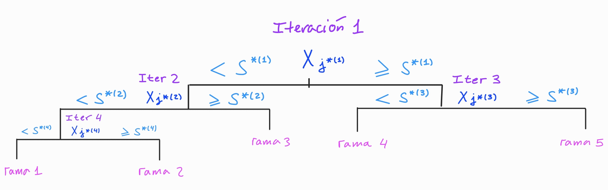

```python
from IPython.display import Image
Image(filename='iter4.jpg', width = 980, height = 350)
```

Siempre que no se cumpla la condición de parada se seguiria haciendo crecer el arbol generando nuevas iteraciones.

No seguiremos exponiendo mas iteraciones del algoritmo, puesto que es facilmente extrapolable lo expuesto a cualquier iteracion superior.